# Racism Within the United States Prison System

Cole Meier

2022-11-01

## Abstract

This analysis is examining the United States prison system, and the potential injustices within it. The data showed that they did not keep record of race in the prison system until the 80’s. Once they began keeping track of race, a definite racial bias appeared in the data. The proportion of incarcerated black people far out weighed their total general population proportion.

## Introduction

The United States has a history of repeated and targeted oppression towards black people in America. This report will specifically dissect the in proportionate incarceration of different races in America. This will be viewing whether there is a direct correlation between race and the likelihood of incarceration in this country. The direct stakeholders for this cause are the millions of minorities in this country that are directly affected by the findings of this report. This has many outside implications, including the amount of single mother homes, generational wealth, and biases that effect the well being of individuals. The goal of this report is to educate the masses on the racism that is ingrained in our society for an area that is often overlooked. This will optimistically aid in chipping away at the matrix of domination in this country. This goal will be achieved by answering the following:

1. What percentage of the prison population is a minority?
2. Which races has the highest proportion of incarceration per capita?
3. Which race has the lowest proportion of incarceration per captia?

Answering thesequestions will enable us to make a complete evaluation of the biases within the prison system in America.

## Data Summary

The proportion of the total number of black people incarcerated is much higher compared to how much of the population they make up. Black people make up around 13% of the population, but they make up on average 27% of the total prison population. Compared to white population which makes up around 57% of the total population, but only make up on average 45 percent of the total prison population. This points to possible racial bias in the American prison system. Another important statistic is the top-5 states with the highest incarceration. Most of the states on the list are more expected due to their large populations, however, Georgia is outside the top 5 highest total population, but is number 4 in total incarcerated population. This shows the possibility of an unfair judicial system and over policing in Georgia.

## Growth of the U.S. Prison Population

This bar graph is a representation of the total jail populations from 1970 to 2018. This shows that the number of people in jail was steady through the seventies. Then is started rapidly raising until the peak in 2008. Since 2008, the total jail population has remained relatively consistent.

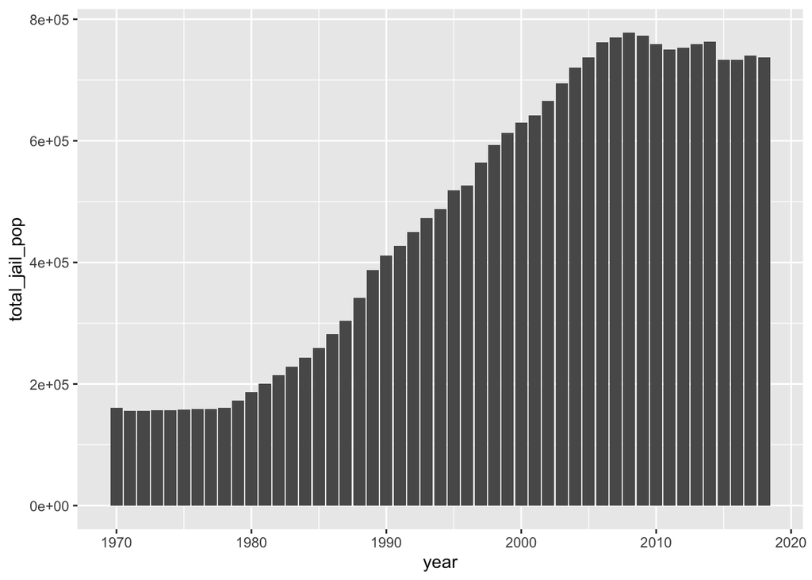

The total prison population by year

## Growth of Prison Population by State

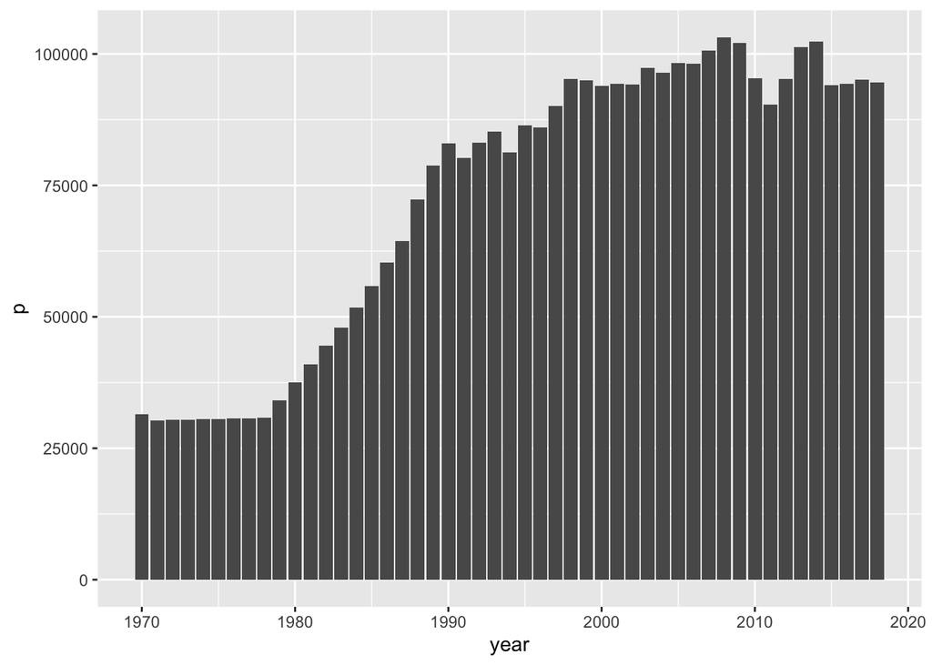

Total jail population of Washington, California, and Oregon, from 1970 to 2018.

## Growth of Black Prison Population

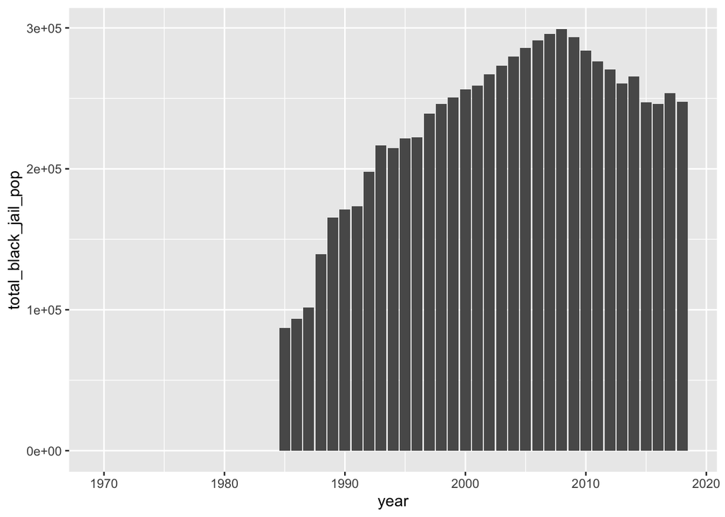

Total jail population of black people in America

This is the representation of the two cities with the highest amount of black people incarcerated in 2018. These locations can signify how the injustice of black people in prison can become normalized within the culture. These areas most likely also have higher numbers of black families without parental figures in the home because of this injustice.

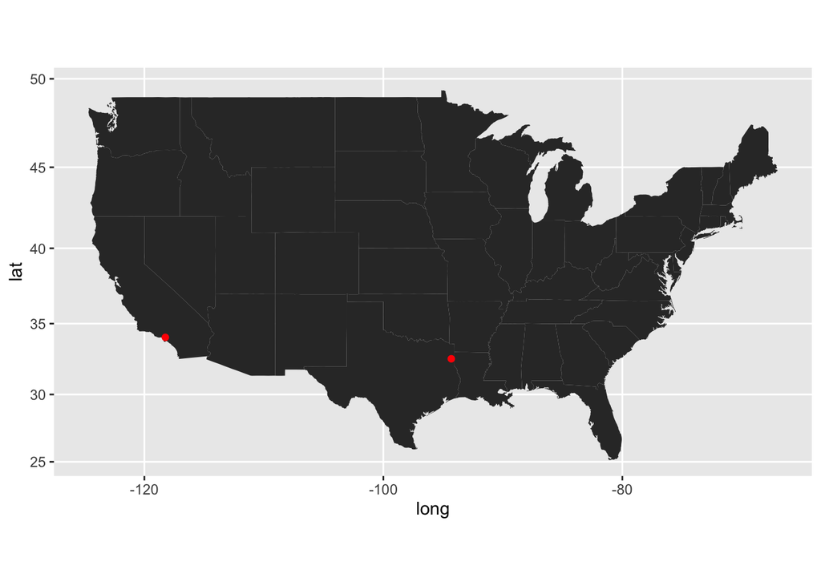

The cities with the highest number of incarcerated black people in 2018